# Geographic projection — concepts you will use

Country-fill choropleth + tree-to-map projection in R

Author

Instructor notes

```r
library(ape)
library(treeio)
library(ggtree)
library(ggplot2)
library(maps)
library(phytools)
library(patchwork)
library(dplyr)
library(tidyr)
library(readr)
library(lubridate)
library(tibble)
```

# Why this document exists

This is a self-contained gallery of the techniques you need for the **geographic-projection** starter project. Every concept is illustrated with a plot generated from the actual project data.

The single question of this starter is: *how can we project a SARS-CoV-2 phylogeny onto a world map?* You will produce two complementary figures (country-fill choropleth, tree-to-map projection) and discuss what they hide about **sampling bias**.

# 1. Three data sources, three country-name conventions

Geographic visualization always starts with **a join**. You want to connect tip metadata (one row per genome) to country polygons (one row per polygon vertex). This works only if the country names line up exactly.

You have three sources:

```r
tree  <- read.tree("data/ncov_subsample.nwk")
meta  <- read_tsv("data/ncov_metadata.tsv", show_col_types = FALSE)
cases <- read_csv("data/covid_cases_per_country.csv", show_col_types = FALSE)
world <- map_data("world")

cat("Tips in tree:                  ", length(tree$tip.label), "\n")
```

```
Tips in tree:                   400
```

```r
cat("Distinct countries in metadata:", length(unique(meta$country)), "\n")
```

```
Distinct countries in metadata: 64
```

```r
cat("Countries in OWID cases CSV:   ", nrow(cases), "\n")
```

```
Countries in OWID cases CSV:    233
```

```r
cat("Polygon-vertex rows in `world`:", nrow(world), "\n")
```

```
Polygon-vertex rows in `world`: 99338
```

```r
cat("Distinct country names in `world`:", length(unique(world$region)), "\n")
```

```
Distinct country names in `world`: 252
```

The country-name discrepancies you will hit:

```r
meta_in_world  <- intersect(unique(meta$country), unique(world$region))
meta_not_world <- setdiff(unique(meta$country), unique(world$region))
meta_not_owid  <- setdiff(unique(meta$country), unique(cases$country))

cat("Metadata countries that DO match world polygons:", length(meta_in_world), "\n")
```

```
Metadata countries that DO match world polygons: 63
```

```r
cat("Metadata countries that don't match `world`:    ", length(meta_not_world), "\n")
```

```
Metadata countries that don't match `world`:     1
```

```r
print(meta_not_world)
```

```
[1] "United Kingdom"
```

```r
cat("Metadata countries that don't match OWID cases: ", length(meta_not_owid), "\n")
```

```
Metadata countries that don't match OWID cases:  2
```

```r
print(meta_not_owid)
```

```
[1] "USA"            "Czech Republic"
```

Plan one tidy step at the top of your script to normalize OWID names to the metadata convention:

```r
cases <- cases %>%
  mutate(country = case_when(
    country == "United States" ~ "USA",
    country == "Czechia"       ~ "Czech Republic",
    TRUE                        ~ country
  ))
```

# 2. A `ggplot2` world map from `map_data("world")`

`maps::map_data("world")` returns a **long data frame** where each row is one vertex of one country polygon. Group those vertices by `group` (NOT by `region` — many countries are split into several disjoint polygons, e.g. Russia by the dateline) and pipe into `geom_polygon`:

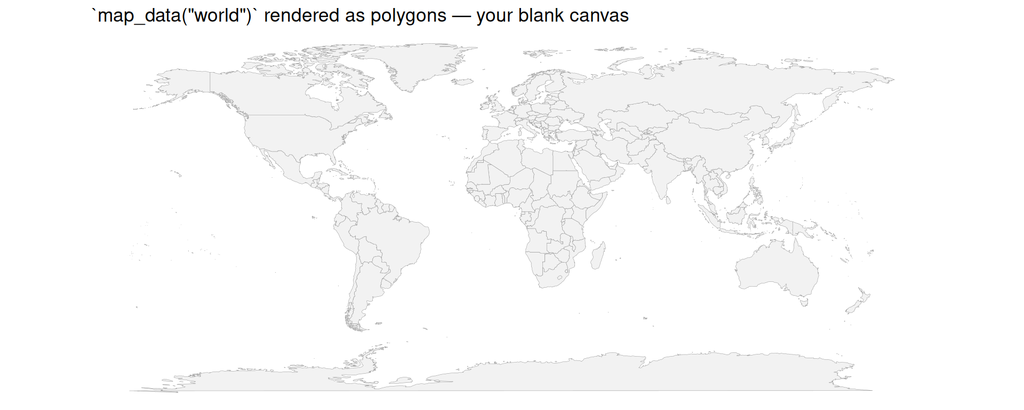

```r
ggplot(world, aes(long, lat, group = group)) +
  geom_polygon(fill = "grey95", color = "grey60", linewidth = 0.1) +
  coord_quickmap() + theme_void() +
  ggtitle("`map_data(\"world\")` rendered as polygons — your blank canvas")
```

# 3. Country-fill choropleth — encoding 1

Compute one summary per country, then fill the polygons by that summary. Here we use **dominant `Nextstrain_clade` per country** as the fill:

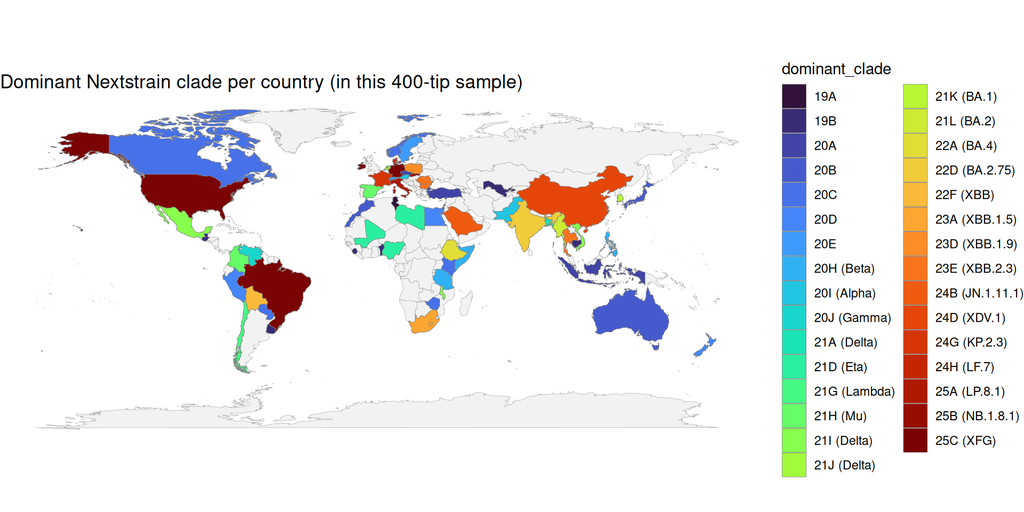

```r
country_clade <- meta %>%
  count(country, Nextstrain_clade) %>%
  group_by(country) %>%
  slice_max(n, n = 1, with_ties = FALSE) %>%
  ungroup() %>%
  rename(dominant_clade = Nextstrain_clade)

p_map <- ggplot() +
  geom_polygon(data = world,
               aes(long, lat, group = group),
               fill = "grey95", color = "grey60", linewidth = 0.1) +
  geom_polygon(data = world %>%
                 inner_join(country_clade, by = c("region" = "country")),
               aes(long, lat, group = group, fill = dominant_clade),
               color = "grey50", linewidth = 0.15) +
  scale_fill_viridis_d(option = "turbo",
                       guide = guide_legend(ncol = 2)) +
  coord_quickmap() + theme_void() +
  ggtitle("Dominant Nextstrain clade per country (in this 400-tip sample)")

p_map
```

Pair it with the same clade information on the tree, side-by-side via `patchwork`:

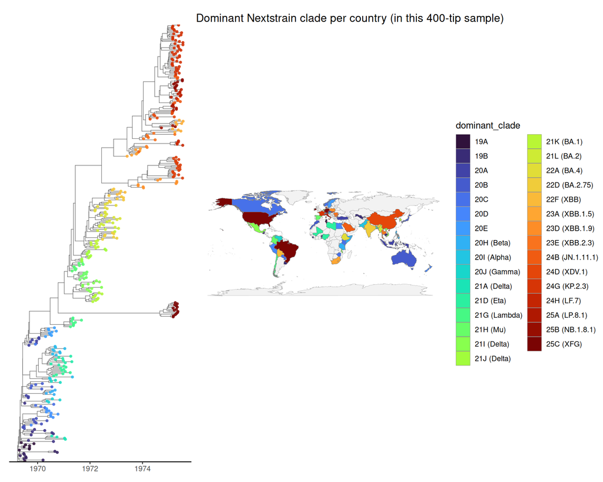

```r
meta <- meta %>% mutate(decimal_date = decimal_date(ymd(date)))
td <- full_join(as_tibble(tree), meta, by = c("label" = "strain")) %>%
  as.treedata()

mrsd_value <- max(meta$decimal_date, na.rm = TRUE)

p_tree <- ggtree(td, mrsd = mrsd_value, as.Date = TRUE,
                 size = 0.25, color = "grey40") +
  geom_tippoint(aes(color = Nextstrain_clade), size = 1.0, alpha = 0.85) +
  scale_color_viridis_d(option = "turbo", name = "Clade",
                        guide = "none") +
  theme_tree2()

(p_tree | p_map) + plot_layout(widths = c(1, 1.4))
```

This single composite figure is the most common publication-style artifact you can produce from tree + country metadata.

# 4. Tree-to-map projection — encoding 2

`phytools::phylo.to.map` connects each tip to its sampling coordinates with a line, drawing the tree on one side and the map on the other. It needs:

- A **rooted, fully-labeled tree** (no internal-node labels needed).
- A **2-column matrix** of coordinates with `tree$tip.label` as row names, columns in the order `c("latitude", "longitude")`, no `NA`s.

```r
coords <- meta %>%
  select(strain, latitude, longitude) %>%
  filter(strain %in% tree$tip.label,
         !is.na(latitude), !is.na(longitude)) %>%
  column_to_rownames("strain") %>%
  as.matrix()

# Drop tips with no coords from the tree, and align the matrix to the new tip order
common  <- intersect(rownames(coords), tree$tip.label)
tree_g  <- ape::keep.tip(tree, common)
coords  <- coords[tree_g$tip.label, c("latitude", "longitude")]

cat("Tips with coordinates:", nrow(coords), "\n")
```

```
Tips with coordinates: 400
```

```r
cat("Coordinate columns:   ", paste(colnames(coords), collapse = ", "), "\n")
```

```
Coordinate columns:    latitude, longitude
```

Then render. The function plots via base graphics, so it does not return a `ggplot` — capture the figure with the chunk’s `fig.height` and `fig.width`:

```r
obj <- phylo.to.map(tree_g, coords, plot = FALSE)
plot(obj, direction = "rightwards", colors = "darkblue",
     cex.points = 0.4, ftype = "off", lwd = 0.25)
```

```
"phylo.to.map" direction is "downwards" but plot direction has been given as "rightwards".
Re-optimizing object....
```

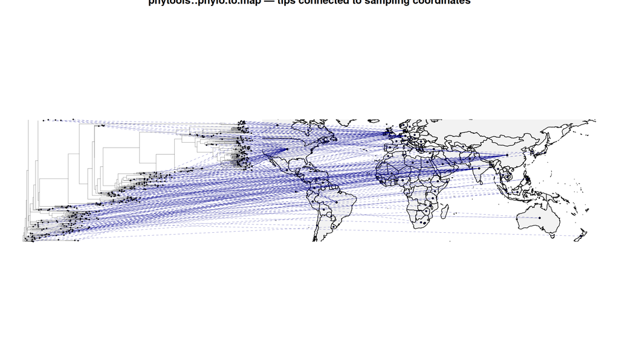

```r
title("phytools::phylo.to.map — tips connected to sampling coordinates")
```

What to look for: **clusters of lines converging on the same map point** are countries with many tips; **lines crossing entire oceans** are tips whose nearest tree-relative is on a different continent (often a sign of travel-related sequencing).

# 5. The critical-thinking step: sampling bias

Both figures so far invite a reader to draw geographic conclusions. *Both* are misleading without one more figure: **how many sequences came from each country?**

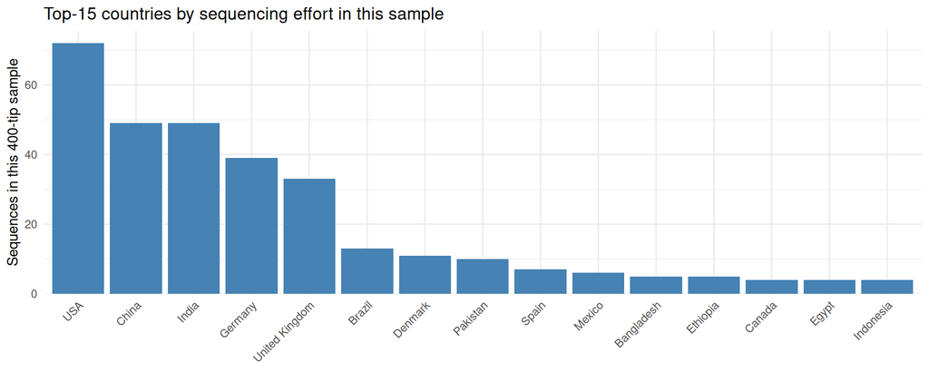

```r
seq_counts <- meta %>%
  count(country, sort = TRUE) %>%
  mutate(country = factor(country, levels = country))

ggplot(seq_counts %>% slice_head(n = 15),
       aes(x = country, y = n)) +
  geom_col(fill = "steelblue") +
  scale_y_continuous(expand = expansion(mult = c(0, 0.05))) +
  labs(x = NULL, y = "Sequences in this 400-tip sample",
       title = "Top-15 countries by sequencing effort in this sample") +
  theme_minimal() +
  theme(axis.text.x = element_text(angle = 45, hjust = 1))
```

A handful of countries dominate. Every conclusion drawn from the choropleth or the projection has to be qualified by this picture.

## 5a. Sequences per million cases — the “intensity” view

Joining the case-count data lets you ask a sharper question: **“who sequences disproportionately”** — i.e. countries whose sequences-per-case ratio is much higher than average.

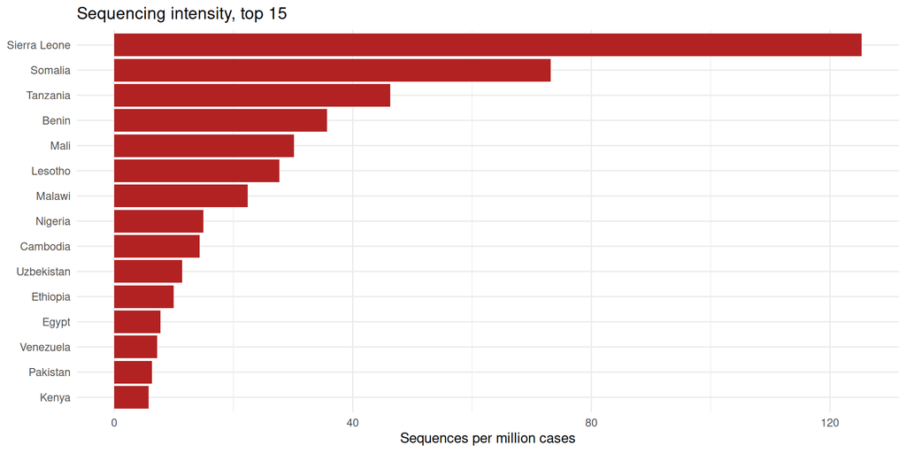

```r
cases_norm <- cases %>%
  mutate(country = case_when(
    country == "United States" ~ "USA",
    country == "Czechia"       ~ "Czech Republic",
    TRUE                        ~ country
  ))

intensity <- seq_counts %>%
  inner_join(cases_norm %>% select(country, total_cases), by = "country") %>%
  mutate(seqs_per_M_cases = n / total_cases * 1e6) %>%
  arrange(desc(seqs_per_M_cases)) %>%
  slice_head(n = 15)

ggplot(intensity, aes(x = reorder(country, seqs_per_M_cases),
                      y = seqs_per_M_cases)) +
  geom_col(fill = "firebrick") +
  coord_flip() +
  labs(x = NULL, y = "Sequences per million cases",
       title = "Sequencing intensity, top 15") +
  theme_minimal()
```

Countries near the top of this bar chart are over-represented in the sample relative to their actual case burden; countries near the *bottom* (often most populous) are under-represented. **The choropleth is silent about this.**

# 6. Pitfalls quick-reference

| Symptom | Cause | Fix |
| --- | --- | --- |
| Half the countries vanish after the choropleth join | Country-name mismatches across sources (`USA` vs `United States`, etc.) | Normalize names with one `case_when()` before joining; check `unique(world$region)` |
| `phylo.to.map` errors with ‘NA in coords’ | Some tips have NA latitude/longitude | Drop them with `keep.tip(tree, common)` before passing the matrix |
| `phylo.to.map` plot is silently rotated / wrong | Coordinate matrix columns out of order or row names misaligned with tip labels | Force `coords[tree$tip.label, c('latitude','longitude')]` after subsetting |
| Choropleth has weird stripes across the dateline | `world` polygons split by `group`, not just `region` | Always group by `group` (each polygon piece), not by `region` |
| Saved phylo.to.map PDF looks unreadable | Default aspect is too tall | Open `pdf(..., width = 14, height = 7)` before plotting |

# 7. Where to go next

- **`SARS-CoV_clade_waves/`** — same tree, different question: *did clades replace each other through time?* Pure tip color, no maps.
- **`SARS-CoV_mutation_heatmap/`** — same tree, different question: *did key spike mutations evolve convergently?* Heatmap encoding, no maps.
- **`SARS-CoV_analysis_project/`** — the full version, where geographic projection is one of six visual encodings layered on the same tree.